# ファミリーBASICのテープセーブ音解析

2021/04/10

## 目的

テープへのセーブデータを解析することで、ファミリーBASICのプログラムを生成できるようにする。  
これによりPC上でコーディングが進められ、開発の効率向上を狙う。

## 方法

データを録音したWAVデータがあるので、これを解析してみる。  
Pythonでライブラリがあるということないが、あるかな？ あった！

```python
import wave
import numpy as np

file = '/Users/kumagai/Music/Cubase LE AI Elements Projects/FamilyBasic/Audio/Firecracker_06.wav'

waveFile = wave.open(file, 'r')
buf = waveFile.readframes(-1)
waveFile.close()
```

データを配列に読み込めた。  
して、配列の中身は？ もしかして文字にすればそのままBASICのコードが出てきたりする？

```python
for b in buf[0:100]:
    if 0x20 <= b <= 0x7f:
        print('%c' % b)
```

```
3
y
:
f
p
R
_
e
~
I
:
.
-
!
```

そんなわけなかった。  
これが音声データだということを思い出す。  
とりあえず値を折れ線グラフにしてみる。

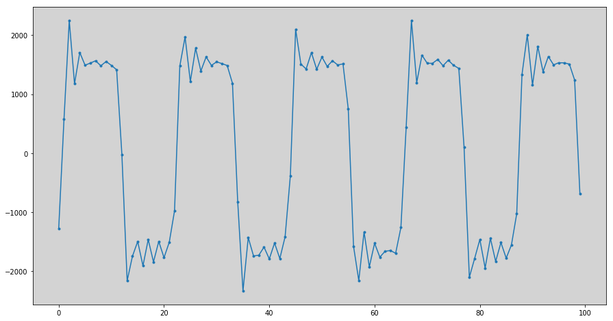

```python
from matplotlib import pyplot as plt
from pylab import rcParams

rcParams['figure.figsize'] = 15,8
samplewidth = waveFile.getsampwidth()
if samplewidth == 2:
    data = np.frombuffer(buf, dtype='int16')
elif samplewidth == 4:
    data = np.frombuffer(buf, dtype='int32')

plt.plot(data[100000:100100], marker='.')
plt.gca().set_facecolor('lightgray')
plt.show()
```

音波と思われる波形が現れ、音声データを相手にしてることがようやく認識できてきた。  
目に見える波形と聴こえる音は一致する？  
およそ22点で１サイクル。サンプリングレート44100ということは44100÷22=2005Hz。2005Hzは440Hzの4.555倍。4.555は2の2.187乗。2.187は2の1/12乗根の24 + 2.25倍。ということは、440Hzの２オクターブ上のラより半音2-3個上の音。聴こえる音とちょうど一致する。  
見方が分かってきたぞ。

```python
import math

a_multi = (44100 / 22) / 440
print(a_multi)
log2 = math.log(a_multi, 2)
print(log2)
log2 * 12 - 24
```

```
4.555785123966942
2.1876997031702885
```

```
2.252396438043462
```

で、どこにどういう形でデータが格納されているか？ まあこの20秒に及ぶ音声のうちデータ正味が表現されているのはほんの一部だと思う。勘だけど、音としてピー・ガーというののガーっていう部分がお目当の部分だと思う。

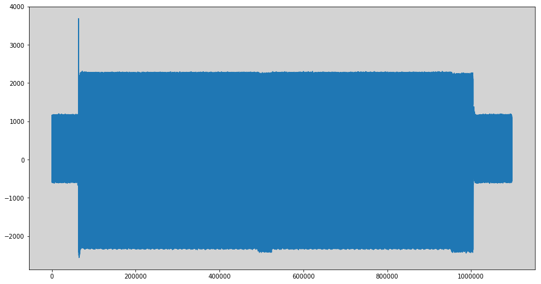

```python
plt.plot(data)
plt.gca().set_facecolor('lightgray')
plt.show()
```

このデータでいうと950000-1000000辺りか？  
このちょっと出っ張ってるところとガーっていうタイミングが符合する気がする。  
ここだとして、ここにどうやってデータが表現されている？ 波形？ 周波数？ 強さ？

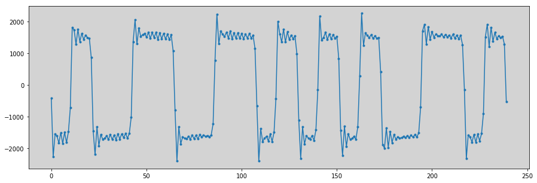

```python
rcParams['figure.figsize'] = 15,5
plt.plot(data[954000:954240], marker='.')
plt.gca().set_facecolor('lightgray')
plt.show()
```

プラスのピークとマイナスのピークの幅が変化してる模様。波形・周波数・強さで言ったら周波数か。  
点の数のバリエーションを挙げていってみる。

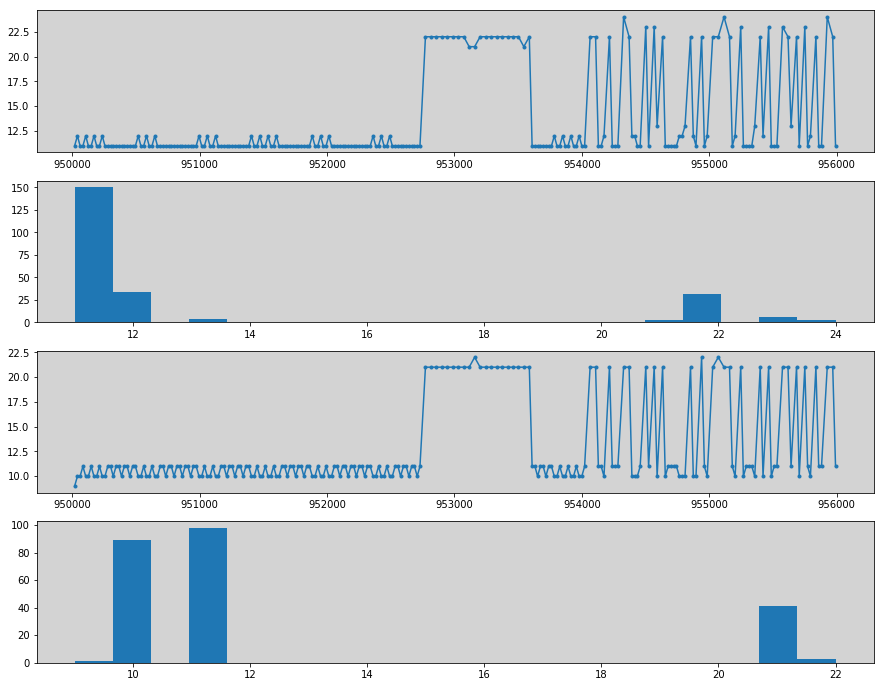

```python
start = 950000
end = 956000
x = []
plus_len = []
minus_len = []
plus_data = []
minus_data = []
pd = None
for i, d in enumerate(data[start:end]):
    if d < 0:
        # minus
        if pd and pd > 0:
            # plus -> minus
            if len(plus_data) > 0 and len(minus_data) > 0:
                x.append(start + i)
                plus_len.append(len(plus_data))
                minus_len.append(len(minus_data))
            minus_data.clear()
            plus_data.clear()
        minus_data.append(d)
    else:
        # plus
        plus_data.append(d)
    pd = d

rcParams['figure.figsize'] = 15,12
fig, ax = plt.subplots(nrows=4)
ax[0].plot(x, plus_len, marker='.')
ax[0].set_facecolor('lightgray')
ax[1].hist(plus_len, bins=20)
ax[1].set_facecolor('lightgray')
ax[2].plot(x, minus_len, marker='.')
ax[2].set_facecolor('lightgray')
ax[3].hist(minus_len, bins=20)
ax[3].set_facecolor('lightgray')
plt.show()
```

点11くらいと22個くらいの２つだけみたいだが、これをどう読む？  
ネット情報を見つけた。

ファミリーベーシック Ｖ２．１Ａ  
http://www43.tok2.com/home/cmpslv/Famic/Fambas.htm

これに当てはめてみる。  
どうだ？

```python
def read_bits(start, end):
    bits = []
    pd = None
    for i, d in enumerate(data[start:end]):
        if d < 0:
            # minus
            if pd is not None and pd >= 0:
                # plus -> minus
                if len(plus_data) > 0 and len(minus_data) > 0:
                    if len(plus_data) <= 15:
                        b1 = 0
                    else:
                        b1 = 1
                    bits.append(b1)

                plus_data.clear()
                minus_data.clear()
            minus_data.append(d)
        else:
            # plus
            plus_data.append(d)
        pd = d
    return bits

def bits_to_bytes(bits):
    byte = 0
    byte_count = 0
    bytes_ = []
    for b in bits:
        byte = (byte << 1) + b
        byte_count += 1
        if byte_count == 9:
            byte -= 0x100
            bytes_.append(byte)
            byte = 0
            byte_count = 0
    return bytes_

def read_info_data(bits):
    count = 0
    pb = None
    area = False
    total_len = 0
    checksum = 0
    bits2 = []
    info_block = None
    lines= []
    for i, b in enumerate(bits):
        if pb is not None:
            if b == pb:
                count += 1
            else:
                count = 1

        if area == 0:
            # インフォーメーションブロック前
            if b > 0:
                checksum += 1
            if b == 1 and count == 40:
                area = 1

        elif area == 1:
            # インフォーメーションブロック-テープマーク１後
            if b > 0:
                checksum += 1
            if b == 0 and count == 40:
                area = 2

        elif area == 2:
            # インフォーメーションブロック-テープマーク２後
            area = 3

        elif area == 3:
            # インフォーメーションブロック-正味
            checksum += b

            bits2.append(b)
            if len(bits2) == 9 * 128:
                info_bytes = bits_to_bytes(bits2)
                info_block = {'attribute' : info_bytes[0],
                                     'filename' : ['%c' % c for c in info_bytes[1:17]],
                                     'length' : info_bytes[18] + info_bytes[19] * 0x100}
                bits2.clear()
                area = 4

        elif area == 4:
            # インフォーメーションブロック-チェックサム
            bits2.append(b)
            if len(bits2) == 9 * 2:
                ckecksum_bytes = bits_to_bytes(bits2)
                print('checksum=%x %x %x' % (ckecksum_bytes[0], ckecksum_bytes[1], checksum))
                bits2.clear()
                area = 10
                chechsum = 0

        elif area == 10:
            # データブロック-テープマーク１後
            if b > 0:
                checksum += 1
            if pb == 1 and count == 20:
                area = 11

        elif area == 11:
            # データブロック-テープマーク２後
            if b > 0:
                checksum += 1
            if pb == 0 and count == 20:
                area = 12

        elif area == 12:
            # データブロック-テープマーク２後
                area = 13

        elif area == 13:
            # データブロック-バイト数
            if b > 0:
                checksum += 1
            bits2.append(b)
            if len(bits2) == 9 * 1:
                length_bytes = bits_to_bytes(bits2)
                line_len = length_bytes[0]
                bits2.clear()
                area = 14

        elif area == 14:
            # データブロック-行番号・テキスト
            if b > 0:
                checksum += 1

            bits2.append(b)
            if len(bits2) == 9 * (line_len - 1):

                line_bytes = bits_to_bytes(bits2)
                total_len += line_len + 2

                line = '%d ' % line_bytes[0]
                for byte in line_bytes[2:-1]:
                    if 0x20 <= byte <= 0x7f:
                        line += '%c' % byte
                    else:
                        line += '%x' % byte

                lines.append(line)
                if total_len + 1 >= info_block['length']:
                    area = 15
                else:
                    area = 13
                bits2.clear()

        elif area == 15:
            # データブロック-チェックサム
            bits2.append(b)
            if len(bits2) == 9 * 2:
                ckecksum_bytes = bits_to_bytes(bits2)
                print('checksum=%x %x' % (ckecksum_bytes[0], ckecksum_bytes[1]))
                bits2.clear()
                area = 16

        pb = b

    return info_block, lines

bits = read_bits(0, 1100000)
info_block, lines = read_info_data(bits)
print(info_block)
for line in lines:
    print(line)
```

```
checksum=0 4a f3
checksum=0 1
{'attribute': 2, 'filename': [' ', ' ', ' ', ' ', ' ', ' ', ' ', ' ', ' ', ' ', ' ', ' ', ' ', ' ', ' ', ' '], 'length': 181}
10 ' FIRECRACKER
20 ' 2019/08/13
30 '
40 a3 "T7M1Y2O4D1E0DO3BRARGRERDRER"
50 a3 "GAGEDRO2BRARBRO3DRER"
60 a3 "DEDO2BARO3DEDO2BARO3DEDO2B"
70 a3 "ARARBRBRO3DRDRERER"
80 a3 "G4G4R1AB4B4"
```

やった！ BASICのソースがそのまま読み出せた！  
a3ってのがよく分からんが、PLAYを意味するのかな？  
あと、チェックサムが一致しないのはデータの生成まで考えるとまだ課題が残るな。